# Generating Crop Phenology Curves in R

Wes Porter

February 23, 2018

When I’m not wrestling with my Oracle database, I’m usually doing remote sensing work. Most of what I’ve been working on lately is an attempt to create crop phenology curves. If you’re not an agronomist, don’t worry I’m not either. I had no idea what phenology curves were until I needed to use them to classify crops from space. Essentially phenology curves are just a measurement of crop growth throughout the year.

This post is just a quick code-along which shows you how to generate phenology curves using R.

I’ll try to always list any packages or addins I use so that if anyone else wants to work along, they know what I’m using. Nothing’s more annoying than orphaned functions and having to hunt down packages. Also the link to download the data is public so it should be available to play around with as well.

```r
library(dplyr)
library(magrittr)
library(readr)
```

## The Data

This past weekend I spent some time writing a python script (more on this later) that calculated the average NDVI value for a few thousand fields in the Mississippi Delta region for 20 days in 2000. The Delta is one of the most agriculturally productive regions in the country, which makes it a good target if we want to look at crop growth over time.

```r
# Read in NDVI data
# readr::read_csv(https://www.dropbox.com/s/rvqgnxc70gv4bhl/ndvi_stats_2000.csv?dl=1, guess_max = 1001)
ndvi_stats_2000 <- readr::read_csv('https://www.dropbox.com/s/rvqgnxc70gv4bhl/ndvi_stats_2000.csv?dl=1', guess_max = 10001)
```

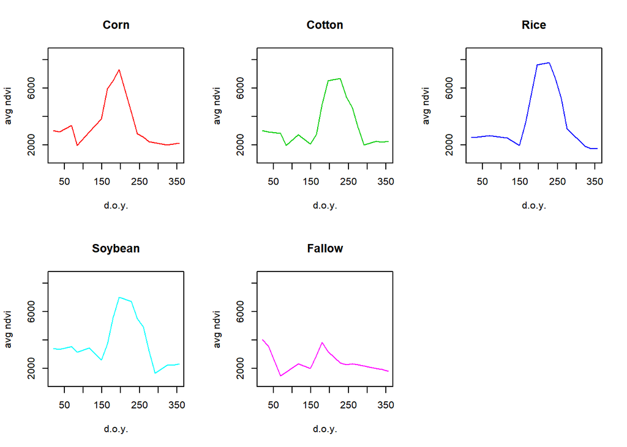

```r
# Filter by crop type
corn <- filter(ndvi_stats_2000, ndvi_stats_2000$cdl == 1)
cotton <- filter(ndvi_stats_2000, ndvi_stats_2000$cdl == 2)
rice <- filter(ndvi_stats_2000, ndvi_stats_2000$cdl == 3)
soybeans <- filter(ndvi_stats_2000, ndvi_stats_2000$cdl == 5)
fallow <- filter(ndvi_stats_2000, ndvi_stats_2000$cdl == 61)

# Filter out no data
corn <- filter(corn, corn$avg > 0)
cotton <- filter(cotton, cotton$avg > 0)
rice <- filter(rice, rice$avg > 0)
soybeans <- filter(soybeans, soybeans$avg > 0)
fallow <- filter(fallow, fallow$avg > 0)

# Calculate stats on cleaned data
corn %>%
  group_by(doy) %>%
    summarise(average = mean(avg), maximum = max(avg),
              minimum = min(avg), stdev = sd(avg) ) -> corn_stats

cotton %>%
  group_by(doy) %>%
  summarise(average = mean(avg), maximum = max(avg),
            minimum = min(avg), stdev = sd(avg) ) -> cotton_stats

rice %>%
  group_by(doy) %>%
  summarise(average = mean(avg), maximum = max(avg),
            minimum = min(avg), stdev = sd(avg) ) -> rice_stats

soybeans %>%
  group_by(doy) %>%
  summarise(average = mean(avg), maximum = max(avg),
            minimum = min(avg), stdev = sd(avg) ) -> soybeans_stats

fallow %>%
  group_by(doy) %>%
  summarise(average = mean(avg), maximum = max(avg),
            minimum = min(avg), stdev = sd(avg) ) -> fallow_stats

# Gather stats
crops <- list(corn_stats, cotton_stats, rice_stats,
              soybeans_stats, fallow_stats)
crop_names <- c('Corn','Cotton','Rice','Soybean','Fallow')
par(mfrow=c(2,3)) # all plots on one page

c <- 2
for(i in 1:length(crops)){

  crop <- crops[[i]]

  heading = crop_names[i]
  plot(x=crop$doy, y=crop$average, ylim=c(1000, 8500), type="l",
       main=heading, col = c, xlab = 'd.o.y.', ylab = 'avg ndvi')
  lines(x=crop$doy, y=crop$average, type="l", col = c)
  c <- c + 1
}
```